# HW1_AsuNazYıldırım

Regression Modeling for S11: • Given that S11 parameters are evaluated at 201 frequency points, predicting them simultaneously through multitarget regression may be computationally intensive and beyond the scope of the content covered so far. Instead, can we simplify the regression task by focusing on predicting S11 at a few key frequency points? For instance, selecting frequencies of interest where the behavior is most critical (e.g., resonance frequencies) can reduce the complexity of the task. Since S11 parameters depend on the frequency, output data composes of multiple columns. To simplify the task, instead of multitarget regression, if we focus on S11 at a few key frequency points, we will ignore how frequency and S11 parameters are related. However, we may think that if we can detect the frequency points beforehand, these points would be where we want to design antennas. Therefore, the task can be reduced to design antennas at the selected frequencies where antenna behavior is the most important. In this case, another criterion appears: what are these key frequency points? This can be done in several ways as we will describe below. After detecting these frequencies, we will perform linear regression to understand the relation between the design and S11 parameter at the selected frequencies.

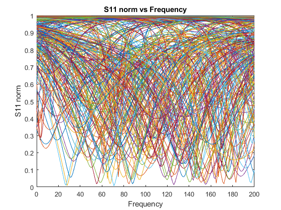

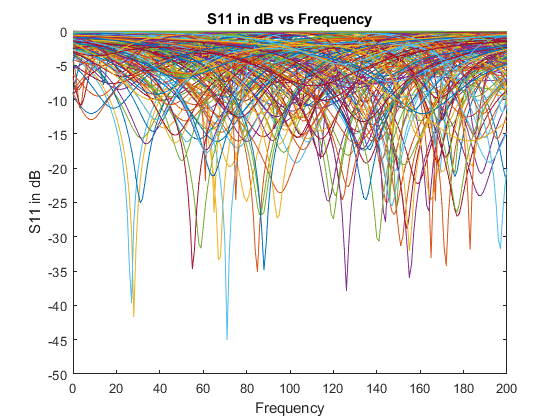

```matlab
img_data = readtable("C:\Users\asuna\OneDrive\Masaüstü\IE\hw1_files/hw1_img.csv", 'VariableNamingRule', 'preserve');
s11_img_part_wfreq = table2array(img_data);
real_data = readtable("C:\Users\asuna\OneDrive\Masaüstü\IE\hw1_files/hw1_real.csv", 'VariableNamingRule', 'preserve');
s11_real_part_wfreq = table2array(real_data);

s11_freq = s11_img_part_wfreq(1,:);
s11_img_part = s11_img_part_wfreq(2:end,:);
s11_real_part = s11_real_part_wfreq(2:end,:);
s11_norm = (s11_img_part.^2 + s11_real_part.^2).^0.5;
s11_desibel = 20*log10(s11_norm);

figure;
plot(s11_freq,s11_norm)
xlabel("Frequency")
ylabel("S11 norm")
title("S11 norm vs Frequency")
figure;
plot(s11_freq,s11_desibel)
xlabel("Frequency")
ylabel("S11 in dB")
title("S11 in dB vs Frequency")
```

To visualize the data, I plotted S11 vs frequency both in terms of norm and decibel. However, selecting frequencies in terms of decibel is more meaningful because antenna design standard is reported based on dB scale [3][5].

One method to identify key frequency points is to check the variance of S11 at each frequency point. The frequency where S11 has the maximum variance may be considered as the critical point and can be investigated.

```matlab
variance_s11_desibel = var(s11_desibel);
[sorted_variance ,index] = sort(variance_s11_desibel,"descend");
freq_index = index-1;
result_table = table(sorted_variance',freq_index','VariableNames',{'Variance','Frequency'});
disp(result_table);
```

```
    Variance    Frequency
    ________    _________

     18.946        146
     18.172        145
     18.163        147
     17.896        144
     17.889        149
     17.761        155
     17.698        148
     17.229         71
     17.225        150
     17.191        143
     17.173        154
     16.903        151
      16.89         88
     16.685        153
     16.653        152
     16.636        126
     16.503         85
     16.465         87
     16.414        142
     16.321        156
     16.249         86
      16.18        141
     15.841         89
     15.769        140
     15.632        125
      15.59        165
     15.565        127
     15.428         84
     15.252         67
     15.238        139
     15.228        135
      15.18         68
     15.158        134
     15.145        167
      15.13        136
     15.076         93
      15.03         94
```

[output cut: 149 more lines]

```
     3.1433         14
     2.9915         13
      2.863         12
     2.7778         11
      2.711         10
     2.6401          9
     2.6399          4
     2.6118          3
     2.5649          8
     2.5383          5
     2.5079          7
     2.4923          6
       2.38          2
     2.1984          1
     2.1116          0
```

[figure not shown]

```
Linear Regression Model for S11 img part at frequency 146 in the original space.

mdl =


Linear regression model:
    y ~ 1 + x1 + x2 + x3 + x4 + x5 + x6 + x7 + x8 + x9 + x10 + x11

Estimated Coefficients:
                   Estimate        SE         tStat        pValue
                   _________    ________    _________    __________

    (Intercept)      0.60871     0.16062       3.7897     0.0001758
    x1             -0.021614    0.015816      -1.3666       0.17256
    x2              0.098748    0.033755       2.9254       0.00365
    x3                2.7885      1.7243       1.6171       0.10669
    x4              -0.93454     0.14692      -6.3608    5.8775e-10
    x5              -0.34002     0.63539     -0.53513       0.59288
    x6               -5.5662      1.4572      -3.8198     0.0001564
    x7             -0.029394      2.1183    -0.013876       0.98894
    x8               0.80673     0.70745       1.1403       0.25488
    x9              -0.86598     0.13694      -6.3237    7.3059e-10
    x10             0.023413    0.019956       1.1732       0.24146
    x11            0.0030761    0.017393      0.17686       0.85972


Number of observations: 385, Error degrees of freedom: 373
Root Mean Squared Error: 0.294
R-squared: 0.308,  Adjusted R-Squared: 0.288
F-statistic vs. constant model: 15.1, p-value = 2.62e-24
Mean Squared Error (MSE): 0.083638
```

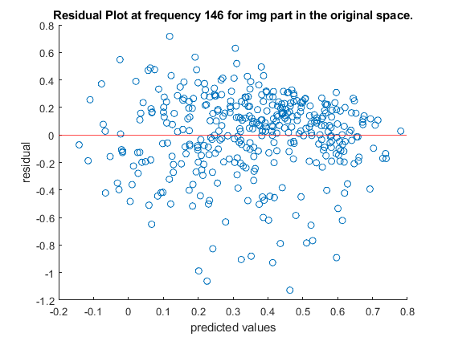

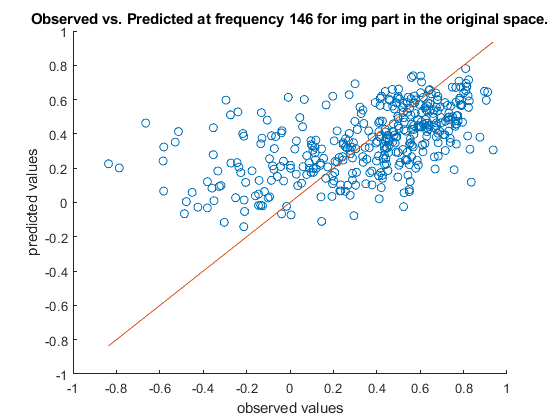

```matlab
freq_point_with_max_variance = freq_index(1) + 1;
addpath('C:\Users\asuna\OneDrive\Masaüstü\IE')
MLR(design_parameters,s11_img_part,freq_point_with_max_variance,"img", "original")
```

```
Linear Regression Model for S11 real part at frequency 146 in the original space.

mdl =


Linear regression model:
    y ~ 1 + x1 + x2 + x3 + x4 + x5 + x6 + x7 + x8 + x9 + x10 + x11

Estimated Coefficients:
                   Estimate        SE        tStat       pValue
                   _________    ________    _______    __________

    (Intercept)       -1.575      0.1554    -10.135    1.7498e-21
    x1              0.036802    0.015302     2.4051      0.016652
    x2                0.1293    0.032657     3.9593     9.004e-05
    x3                1.3197      1.6682    0.79105       0.42942
    x4                1.4406     0.14214     10.135    1.7492e-21
    x5                1.0268     0.61473     1.6703      0.095695
    x6                -3.408      1.4098    -2.4173      0.016115
    x7                -2.415      2.0494    -1.1784       0.23938
    x8               0.58839     0.68445    0.85965       0.39053
    x9              0.019819     0.13249    0.14959       0.88117
    x10             0.050815    0.019307     2.6319     0.0088435
    x11            0.0053271    0.016827    0.31657       0.75175


Number of observations: 385, Error degrees of freedom: 373
Root Mean Squared Error: 0.284
R-squared: 0.8,  Adjusted R-Squared: 0.794
F-statistic vs. constant model: 135, p-value = 6.8e-123
Mean Squared Error (MSE): 0.078287
```

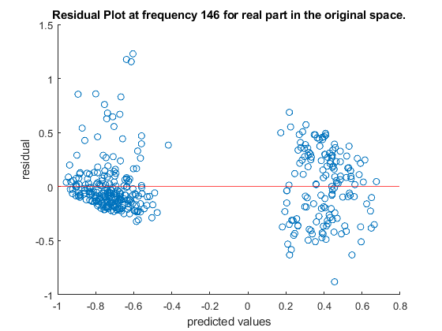

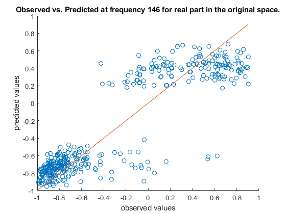

```matlab
MLR(design_parameters,s11_real_part,freq_point_with_max_variance, "real", "original")
```

```
Linear Regression Model for S11 img part at frequency 145 in the original space.

mdl =


Linear regression model:
    y ~ 1 + x1 + x2 + x3 + x4 + x5 + x6 + x7 + x8 + x9 + x10 + x11

Estimated Coefficients:
                   Estimate        SE         tStat        pValue
                   _________    ________    _________    __________

    (Intercept)      0.58629     0.16007       3.6628    0.00028557
    x1             -0.019659    0.015761      -1.2473       0.21306
    x2               0.10106    0.033638       3.0042     0.0028422
    x3                2.8295      1.7183       1.6466       0.10047
    x4              -0.94992     0.14641       -6.488    2.7689e-10
    x5              -0.26562     0.63319     -0.41949        0.6751
    x6                -5.613      1.4521      -3.8653    0.00013083
    x7              -0.17179      2.1109    -0.081383       0.93518
    x8               0.84536       0.705       1.1991       0.23125
    x9              -0.86502     0.13647      -6.3387    6.6936e-10
    x10             0.026315    0.019887       1.3233       0.18656
    x11            0.0020436    0.017333      0.11791       0.90621


Number of observations: 385, Error degrees of freedom: 373
Root Mean Squared Error: 0.293
R-squared: 0.311,  Adjusted R-Squared: 0.291
F-statistic vs. constant model: 15.3, p-value = 1.15e-24
Mean Squared Error (MSE): 0.083058
```

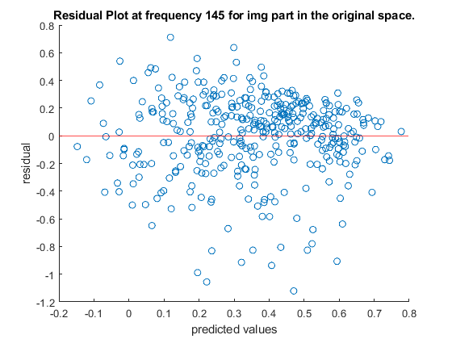

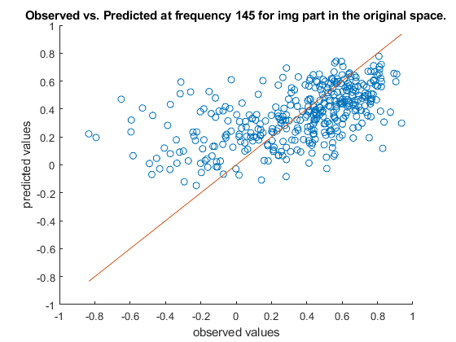

```matlab
freq_point_with_2nd_max_variance = freq_index(2) + 1;
MLR(design_parameters,s11_img_part,freq_point_with_2nd_max_variance,"img", "original")
```

```
Linear Regression Model for S11 real part at frequency 145 in the original space.

mdl =


Linear regression model:
    y ~ 1 + x1 + x2 + x3 + x4 + x5 + x6 + x7 + x8 + x9 + x10 + x11

Estimated Coefficients:
                   Estimate        SE        tStat       pValue
                   _________    ________    _______    __________

    (Intercept)      -1.5914     0.15657    -10.164    1.3821e-21
    x1              0.039091    0.015417     2.5357      0.011631
    x2               0.12786    0.032903     3.8858    0.00012068
    x3                1.3212      1.6808    0.78605       0.43234
    x4                1.4405     0.14321     10.059    3.2226e-21
    x5                1.0511     0.61936     1.6971      0.090511
    x6               -3.3749      1.4204    -2.3759      0.018009
    x7               -2.4447      2.0648     -1.184       0.23717
    x8               0.61347      0.6896    0.88961       0.37425
    x9               0.03308     0.13349    0.24781       0.80442
    x10             0.052525    0.019453     2.7002     0.0072462
    x11            0.0053404    0.016954    0.31499       0.75294


Number of observations: 385, Error degrees of freedom: 373
Root Mean Squared Error: 0.286
R-squared: 0.797,  Adjusted R-Squared: 0.791
F-statistic vs. constant model: 133, p-value = 9.57e-122
Mean Squared Error (MSE): 0.07947
```

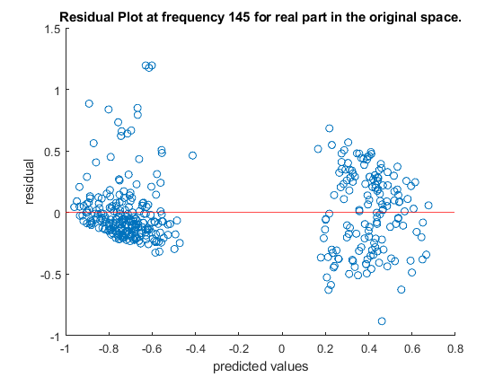

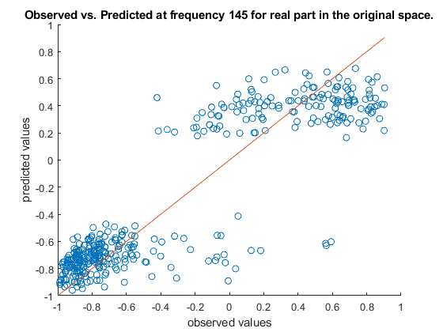

```matlab
MLR(design_parameters,s11_real_part,freq_point_with_2nd_max_variance, "real", "original")
```

```
Linear Regression Model for S11 img part at frequency 155 in the original space.

mdl =


Linear regression model:
    y ~ 1 + x1 + x2 + x3 + x4 + x5 + x6 + x7 + x8 + x9 + x10 + x11

Estimated Coefficients:
                   Estimate        SE        tStat       pValue
                   _________    ________    _______    __________

    (Intercept)       0.6798     0.15913      4.272    2.4622e-05
    x1             -0.025381    0.015669    -1.6199       0.10611
    x2              0.088967    0.033441     2.6604     0.0081414
    x3                2.9549      1.7083     1.7297      0.084504
    x4              -0.90373     0.14555    -6.2089    1.4232e-09
    x5               -0.6579     0.62949    -1.0451       0.29664
    x6               -5.4555      1.4437     -3.779    0.00018327
    x7               0.45821      2.0986    0.21834       0.82728
    x8               0.63817     0.70087    0.91054       0.36312
    x9              -0.83609     0.13567    -6.1627    1.8558e-09
    x10             0.016477    0.019771    0.83339       0.40516
    x11            0.0076544    0.017231    0.44422       0.65714


Number of observations: 385, Error degrees of freedom: 373
Root Mean Squared Error: 0.291
R-squared: 0.314,  Adjusted R-Squared: 0.294
F-statistic vs. constant model: 15.5, p-value = 6.13e-25
Mean Squared Error (MSE): 0.08209
```

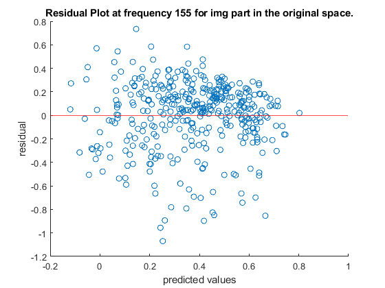

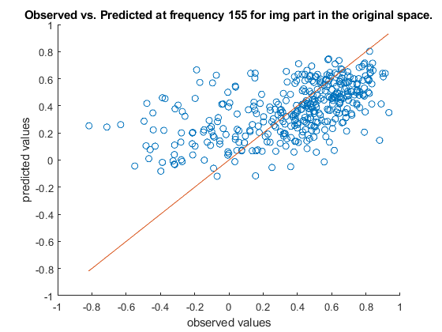

```matlab
MLR(design_parameters,s11_img_part,155+1, "img", "original")
```

```
Linear Regression Model for S11 real part at frequency 155 in the original space.

mdl =


Linear regression model:
    y ~ 1 + x1 + x2 + x3 + x4 + x5 + x6 + x7 + x8 + x9 + x10 + x11

Estimated Coefficients:
                   Estimate        SE        tStat        pValue
                   _________    ________    ________    __________

    (Intercept)       -1.422     0.14961     -9.5048    2.5086e-19
    x1               0.01795    0.014731      1.2185       0.22379
    x2               0.13376     0.03144      4.2546    2.6514e-05
    x3                1.4781       1.606     0.92032         0.358
    x4                1.4768     0.13684      10.792    8.2279e-24
    x5               0.51407     0.59181     0.86863       0.38561
    x6               -3.6396      1.3573     -2.6816     0.0076528
    x7               -1.9311       1.973    -0.97877       0.32833
    x8               0.35893     0.65893     0.54471       0.58628
    x9             -0.097264     0.12755    -0.76256       0.44621
    x10             0.034396    0.018587      1.8505      0.065032
    x11             0.011383      0.0162     0.70265       0.48271


Number of observations: 385, Error degrees of freedom: 373
Root Mean Squared Error: 0.274
R-squared: 0.816,  Adjusted R-Squared: 0.81
F-statistic vs. constant model: 150, p-value = 1.38e-129
Mean Squared Error (MSE): 0.072559
```

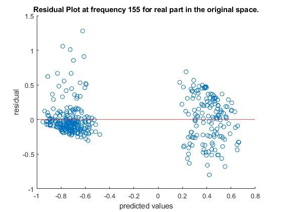

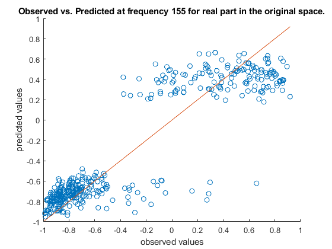

```matlab
MLR(design_parameters,s11_real_part,155+1, "real", "original")
```

```
Linear Regression Model for S11 img part at frequency 71 in the original space.

mdl =


Linear regression model:
    y ~ 1 + x1 + x2 + x3 + x4 + x5 + x6 + x7 + x8 + x9 + x10 + x11

Estimated Coefficients:
                   Estimate       SE        tStat        pValue
                   ________    ________    ________    __________

    (Intercept)     0.08632     0.15935      0.5417       0.58835
    x1              0.04204    0.015691      2.6793     0.0077044
    x2             0.058967    0.033488      1.7609      0.079081
    x3               1.5806      1.7107     0.92396        0.3561
    x4             -0.80046     0.14576     -5.4917    7.3762e-08
    x5              0.58391     0.63036     0.92631       0.35488
    x6              -4.3011      1.4457     -2.9752     0.0031187
    x7             -0.38365      2.1015    -0.18256       0.85524
    x8                1.503     0.70185      2.1414      0.032886
    x9             -0.52127     0.13586     -3.8369    0.00014631
    x10            0.030911    0.019798      1.5613        0.1193
    x11            0.022623    0.017255      1.3111       0.19064


Number of observations: 385, Error degrees of freedom: 373
Root Mean Squared Error: 0.291
R-squared: 0.28,  Adjusted R-Squared: 0.259
F-statistic vs. constant model: 13.2, p-value = 2.86e-21
Mean Squared Error (MSE): 0.082319
```

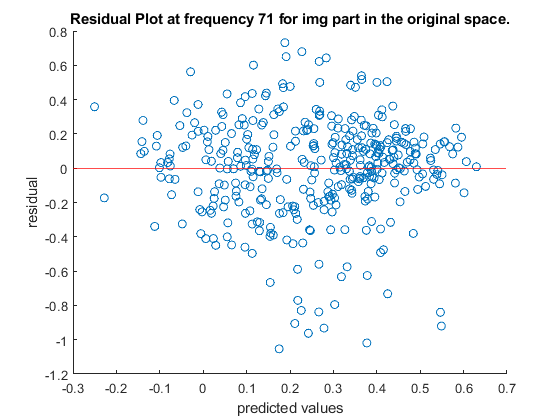

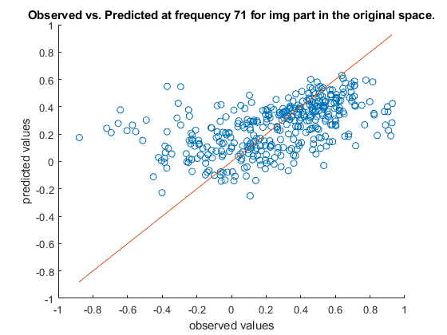

```matlab
MLR(design_parameters,s11_img_part,71+1, "img", "original")
```

```
Linear Regression Model for S11 real part at frequency 71 in the original space.

mdl =


Linear regression model:
    y ~ 1 + x1 + x2 + x3 + x4 + x5 + x6 + x7 + x8 + x9 + x10 + x11

Estimated Coefficients:
                    Estimate        SE        tStat        pValue
                   __________    ________    ________    __________

    (Intercept)       -1.0089      0.1685     -5.9876    5.0082e-09
    x1             -0.0077022    0.016591    -0.46423       0.64275
    x2               0.095625     0.03541      2.7005     0.0072392
    x3               -0.36518      1.8089    -0.20188       0.84012
    x4                 1.8402     0.15412       11.94    4.7485e-28
    x5               -0.48241     0.66655    -0.72375       0.46967
    x6                -3.9731      1.5287     -2.5991     0.0097181
    x7                0.59915      2.2221     0.26963       0.78759
    x8                -0.3863     0.74214    -0.52053       0.60301
    x9                0.37751     0.14366      2.6279     0.0089473
    x10             -0.053689    0.020935     -2.5646      0.010721
    x11               0.01826    0.018246      1.0008       0.31758


Number of observations: 385, Error degrees of freedom: 373
Root Mean Squared Error: 0.308
R-squared: 0.792,  Adjusted R-Squared: 0.786
F-statistic vs. constant model: 129, p-value = 9.08e-120
Mean Squared Error (MSE): 0.092041
```

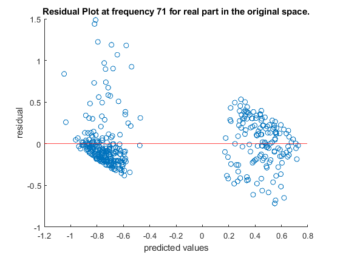

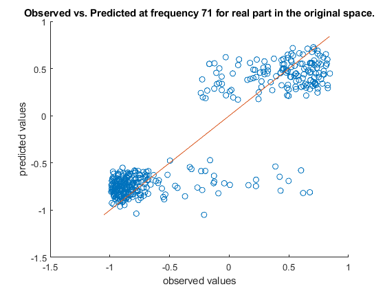

```matlab
MLR(design_parameters,s11_real_part,71+1, "real", "original")
```

Another method to identify key frequency points might be to detect the frequencies where local minima are observed. These frequencies can be interpreted as critical.

```matlab
%all local minimum for each design including first and last frequency
num_rows = size(s11_desibel, 1);
num_cols = size(s11_desibel, 2);
local_min_values_all = cell(num_rows, 1);  % Cell array to store local minima values for each row
local_min_freqs_all = cell(num_rows, 1);   % Cell array to store corresponding frequencies for each row
for row = 1:num_rows
    s11_row = s11_desibel(row, :);
    min_values = [];
    min_freqs = [];
    if s11_row(1) < s11_row(2)
        min_values = [min_values; s11_row(1)];
        min_freqs = [min_freqs; s11_freq(1)];
    end
    for col = 2:(num_cols - 1)
        if s11_row(col) < s11_row(col - 1) && s11_row(col) < s11_row(col + 1)
            min_values = [min_values; s11_row(col)];
            min_freqs = [min_freqs; s11_freq(col)];
        end
    end
    if s11_row(num_cols) < s11_row(num_cols - 1)
        min_values = [min_values; s11_row(num_cols)];
        min_freqs = [min_freqs; s11_freq(num_cols)];
    end
    local_min_values_all{row} = min_values;
    local_min_freqs_all{row} = min_freqs;
end
all_min_freqs = vertcat(local_min_freqs_all{:});
unique_freqs = unique(all_min_freqs);
freq_counts = histc(all_min_freqs, unique_freqs);
frequency_counts_table = table(unique_freqs, freq_counts, 'VariableNames', {'Frequency', 'Count'});
disp(frequency_counts_table);
```

```
    Frequency    Count
    _________    _____

         0        132
         1          1
         3          3
         4          1
         5          1
         8          2
         9          1
        10          3
        12          1
        13          1
        14          2
        15          2
```

[output cut: 148 more lines]

I observed that including first and last frequencies mislead the detection of critical behavior if we look at the plot s11 in decibel vs. frequency. Therefore, I excluded these points.

```matlab
unique_freqs_filtered = unique_freqs(2:end-1);
freq_counts_filtered = freq_counts(2:end-1);
frequency_counts_table_filtered = table(unique_freqs_filtered, freq_counts_filtered, 'VariableNames', {'Frequency Filtered', 'Count Filtered'});
disp(frequency_counts_table_filtered);
```

```
    Frequency Filtered    Count Filtered
    __________________    ______________

             1                  1
             3                  3
             4                  1
             5                  1
             8                  2
             9                  1
            10                  3
            12                  1
            13                  1
            14                  2
            15                  2
            16                  1
```

[output cut: 146 more lines]

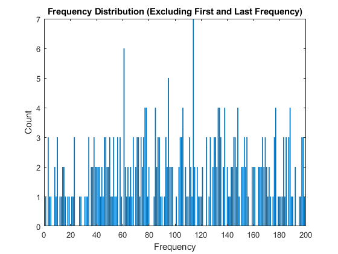

```matlab
figure;
bar(unique_freqs_filtered, freq_counts_filtered);
title('Frequency Distribution (Excluding First and Last Frequency)');
xlabel('Frequency');
ylabel('Count');
```

By using the bar plot, I visualized the "possible distribution" of the local minima.

```matlab
[max_count, idx_max] = max(freq_counts_filtered);
most_frequent_freq = unique_freqs_filtered(idx_max);
disp(['The most frequent frequency for the local minima (excluding first and last) is: ', num2str(most_frequent_freq)]);
disp(['It occurs ', num2str(max_count), ' times.']);
```

```
The most frequent frequency for the local minima (excluding first and last) is: 114
It occurs 7 times.
```

I found the most frequent frequency from the filtered data.

```
Linear Regression Model for S11 img part at frequency 114 in the original space.

mdl =


Linear regression model:
    y ~ 1 + x1 + x2 + x3 + x4 + x5 + x6 + x7 + x8 + x9 + x10 + x11

Estimated Coefficients:
                    Estimate        SE        tStat        pValue
                   __________    ________    ________    __________

    (Intercept)     -0.029081     0.15566    -0.18682        0.8519
    x1               0.036456    0.015327      2.3786      0.017883
    x2                0.11282    0.032712       3.449    0.00062693
    x3                 2.5625       1.671      1.5335       0.12599
    x4                -1.0896     0.14238     -7.6526    1.7007e-13
    x5                0.84161     0.61576      1.3668       0.17251
    x6                 -3.489      1.4122     -2.4707      0.013931
    x7                0.29061      2.0528     0.14157        0.8875
    x8                 1.5559     0.68559      2.2694      0.023816
    x9               -0.79907     0.13271     -6.0212    4.1477e-09
    x10              0.085533    0.019339      4.4227    1.2803e-05
    x11            -0.0069213    0.016855    -0.41063       0.68158


Number of observations: 385, Error degrees of freedom: 373
Root Mean Squared Error: 0.285
R-squared: 0.341,  Adjusted R-Squared: 0.322
F-statistic vs. constant model: 17.6, p-value = 4.47e-28
Mean Squared Error (MSE): 0.078548
```

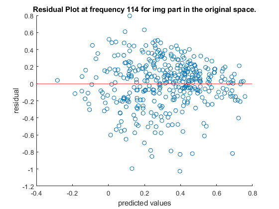

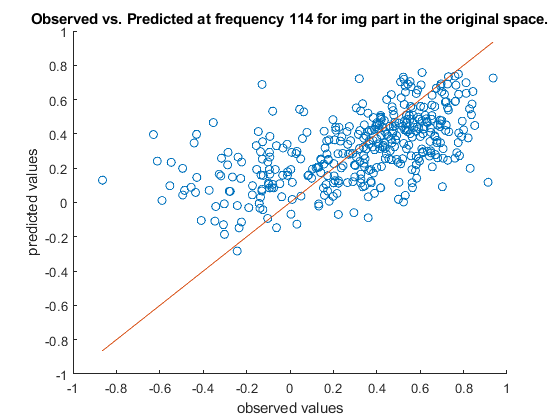

```matlab
res_freq1 = most_frequent_freq+1;
MLR(design_parameters,s11_img_part,res_freq1, "img", "original")
```

```
Linear Regression Model for S11 real part at frequency 114 in the original space.

mdl =


Linear regression model:
    y ~ 1 + x1 + x2 + x3 + x4 + x5 + x6 + x7 + x8 + x9 + x10 + x11

Estimated Coefficients:
                   Estimate        SE        tStat        pValue
                   _________    ________    ________    __________

    (Intercept)      -1.4456     0.16444     -8.7912    5.5123e-17
    x1              0.034466    0.016192      2.1286      0.033941
    x2               0.10496    0.034557      3.0372     0.0025556
    x3              -0.33037      1.7653    -0.18715       0.85165
    x4                1.6181     0.15041      10.758    1.0916e-23
    x5                0.5719     0.65049     0.87919       0.37987
    x6               -3.1042      1.4918     -2.0808      0.038134
    x7                 0.112      2.1686    0.051646       0.95884
    x8              -0.25056     0.72426    -0.34595       0.72957
    x9               0.30129      0.1402       2.149      0.032276
    x10            0.0038993     0.02043     0.19086       0.84874
    x11              0.02494    0.017806      1.4006       0.16216


Number of observations: 385, Error degrees of freedom: 373
Root Mean Squared Error: 0.301
R-squared: 0.782,  Adjusted R-Squared: 0.775
F-statistic vs. constant model: 122, p-value = 5.36e-116
Mean Squared Error (MSE): 0.08766
```

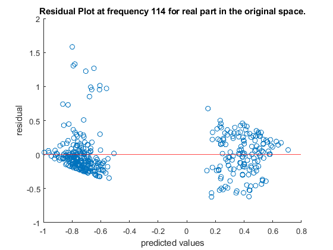

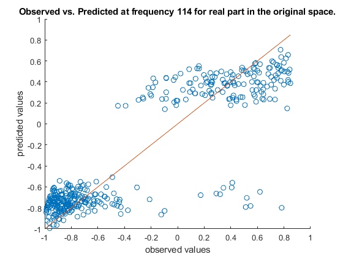

```matlab
MLR(design_parameters,s11_real_part,res_freq1, "real", "original")
```

```
The number of suitable antennas: 161
```

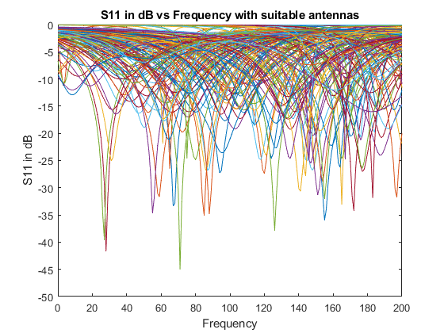

```matlab
rows_to_keep = any(s11_desibel <= -10, 2);
filtered_s11_desibel_matrix = s11_desibel(rows_to_keep, :);
disp(['The number of suitable antennas: ', num2str(size(filtered_s11_desibel_matrix,1))]);
figure;
plot(s11_freq,filtered_s11_desibel_matrix)
xlabel("Frequency")
ylabel("S11 in dB")
title("S11 in dB vs Frequency with suitable antennas")
```

Now, we can apply the same procedure as described above to identify critical points. Let's use the first method.

```matlab
variance_filtered_s11_desibel = var(filtered_s11_desibel_matrix);
[sorted_filtered_variance ,index_filtered] = sort(variance_filtered_s11_desibel,"descend");
freq_index_filtered = index_filtered-1;
result_table_filtered = table(sorted_variance',freq_index_filtered','VariableNames',{'Variance for Filtered Data','Frequency for Filtered Data'});
disp(result_table_filtered);
```

```
    Variance for Filtered Data    Frequency for Filtered Data
    __________________________    ___________________________

              18.946                          146
              18.172                          155
              18.163                          149
              17.896                          147
              17.889                          145
              17.761                          154
              17.698                          144
              17.229                          148
              17.225                          150
              17.191                          151
              17.173                          153
              16.903                          156
               16.89                          152
              16.685                          143
              16.653                           71
              16.636                           88
              16.503                          126
              16.465                           85
              16.414                           87
              16.321                          142
              16.249                          165
               16.18                           86
              15.841                          141
              15.769                          140
              15.632                          125
               15.59                           89
              15.565                          167
              15.428                          127
              15.252                          172
              15.238                          157
              15.228                           84
               15.18                          139
              15.158                          166
              15.145                          171
               15.13                          135
              15.076                          134
               15.03                          136
```

[output cut: 149 more lines]

```
              3.1433                           14
              2.9915                           13
               2.863                           12
              2.7778                           11
               2.711                           10
              2.6401                            4
              2.6399                            9
              2.6118                            3
              2.5649                            8
              2.5383                            5
              2.5079                            7
              2.4923                            6
                2.38                            2
              2.1984                            1
              2.1116                            0
```

```
For the suitable antennas:
Linear Regression Model for S11 img part at frequency 146 in the original space.

mdl =


Linear regression model:
    y ~ 1 + x1 + x2 + x3 + x4 + x5 + x6 + x7 + x8 + x9 + x10 + x11

Estimated Coefficients:
                   Estimate        SE        tStat        pValue
                   _________    ________    ________    __________

    (Intercept)      0.75715     0.30623      2.4725      0.014542
    x1             -0.069234    0.023211     -2.9828     0.0033384
    x2              0.023953    0.064595     0.37082        0.7113
    x3                1.9464      2.8549     0.68175       0.49645
    x4              -0.58511     0.26636     -2.1967      0.029586
    x5              0.024716      1.0361    0.023856         0.981
    x6                -3.788      2.4475     -1.5477       0.12382
    x7              -0.81144      3.3629    -0.24129       0.80966
    x8              -0.38017      1.1725    -0.32423       0.74622
    x9              -0.81216     0.22453     -3.6171    0.00040715
    x10             0.010627    0.044136     0.24078       0.81006
    x11              0.05821    0.028361      2.0525      0.041872


Number of observations: 161, Error degrees of freedom: 149
Root Mean Squared Error: 0.295
R-squared: 0.314,  Adjusted R-Squared: 0.263
F-statistic vs. constant model: 6.19, p-value = 2.44e-08
Mean Squared Error (MSE): 0.080393
```

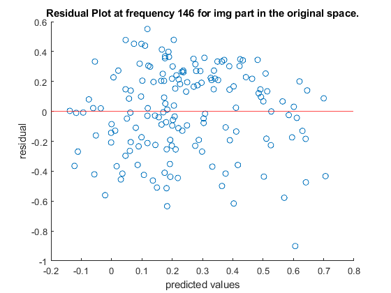

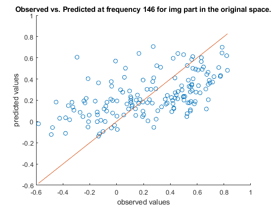

```matlab
filtered_s11_img = s11_img_part(rows_to_keep,:);
filtered_design_para = design_parameters(rows_to_keep,:);
freq_point_with_max_variance_filtered = freq_index_filtered(1) + 1;
disp("For the suitable antennas:")
MLR(filtered_design_para,filtered_s11_img,freq_point_with_max_variance_filtered,"img", "original")
```